# 01b-General-Methylation-Patterns

Laura H Spencer

4/22/2020

### Load libraries

```r
list.of.packages <- c("tidyverse", "reshape2", "here", "methylKit", "scales") #add new libraries here

new.packages <- list.of.packages[!(list.of.packages %in% installed.packages()[,"Package"])]
if(length(new.packages)) install.packages(new.packages)

# Load all libraries
lapply(list.of.packages, FUN = function(X) {
  do.call("require", list(X))
})
```

### Merge all .bam files into one, called “all.merged.bam”, saved in the same directory (my external hard drive)

```bash
samtools merge /Volumes/Peach\ Backup/oly-mbdseq-bismark-files_sorted/all.merged.bam \
/Volumes/Peach\ Backup/oly-mbdseq-bismark-files_sorted/zr1394_1_s456_trimmed_bismark_bt2.deduplicated.sorted.bam \
/Volumes/Peach\ Backup/oly-mbdseq-bismark-files_sorted/zr1394_2_s456_trimmed_bismark_bt2.deduplicated.sorted.bam \
/Volumes/Peach\ Backup/oly-mbdseq-bismark-files_sorted/zr1394_3_s456_trimmed_bismark_bt2.deduplicated.sorted.bam \
/Volumes/Peach\ Backup/oly-mbdseq-bismark-files_sorted/zr1394_4_s456_trimmed_bismark_bt2.deduplicated.sorted.bam \
/Volumes/Peach\ Backup/oly-mbdseq-bismark-files_sorted/zr1394_5_s456_trimmed_bismark_bt2.deduplicated.sorted.bam \
/Volumes/Peach\ Backup/oly-mbdseq-bismark-files_sorted/zr1394_6_s456_trimmed_bismark_bt2.deduplicated.sorted.bam \
/Volumes/Peach\ Backup/oly-mbdseq-bismark-files_sorted/zr1394_7_s456_trimmed_bismark_bt2.deduplicated.sorted.bam \
/Volumes/Peach\ Backup/oly-mbdseq-bismark-files_sorted/zr1394_8_s456_trimmed_bismark_bt2.deduplicated.sorted.bam \
/Volumes/Peach\ Backup/oly-mbdseq-bismark-files_sorted/zr1394_9_s456_trimmed_bismark_bt2.deduplicated.sorted.bam \
/Volumes/Peach\ Backup/oly-mbdseq-bismark-files_sorted/zr1394_10_s456_trimmed_bismark_bt2.deduplicated.sorted.bam \
/Volumes/Peach\ Backup/oly-mbdseq-bismark-files_sorted/zr1394_11_s456_trimmed_bismark_bt2.deduplicated.sorted.bam \
/Volumes/Peach\ Backup/oly-mbdseq-bismark-files_sorted/zr1394_12_s456_trimmed_bismark_bt2.deduplicated.sorted.bam \
/Volumes/Peach\ Backup/oly-mbdseq-bismark-files_sorted/zr1394_13_s456_trimmed_bismark_bt2.deduplicated.sorted.bam \
/Volumes/Peach\ Backup/oly-mbdseq-bismark-files_sorted/zr1394_14_s456_trimmed_bismark_bt2.deduplicated.sorted.bam \
/Volumes/Peach\ Backup/oly-mbdseq-bismark-files_sorted/zr1394_15_s456_trimmed_bismark_bt2.deduplicated.sorted.bam \
/Volumes/Peach\ Backup/oly-mbdseq-bismark-files_sorted/zr1394_16_s456_trimmed_bismark_bt2.deduplicated.sorted.bam \
/Volumes/Peach\ Backup/oly-mbdseq-bismark-files_sorted/zr1394_17_s456_trimmed_bismark_bt2.deduplicated.sorted.bam \
/Volumes/Peach\ Backup/oly-mbdseq-bismark-files_sorted/zr1394_18_s456_trimmed_bismark_bt2.deduplicated.sorted.bam
```

### Create methylKit object the merged .bam file

```r
myobj_merged = processBismarkAln(location = "/Volumes/Peach\ Backup/oly-mbdseq-bismark-files_sorted/all.merged.bam",
                                 assembly = "v081", read.context="CpG", mincov=2, sample.id="all_merged")
```

### Save methylRaw object to file

```r
save(myobj_merged, file = "../analyses/methylation-characteristics/R-objects/myobj_merged")
```

### Read in methylRaw object, if neede

```r
load("../analyses/methylation-characteristics/R-objects/myobj_merged")
```

### Check out format of methylRaw object

```r
head(myobj_merged)
```

```
##       chr start end strand coverage numCs numTs
## 1 Contig0   159 159      +        2     2     0
## 2 Contig0   162 162      +        2     2     0
## 3 Contig0    36  36      +       56     0    56
## 4 Contig0   160 160      -        5     4     1
## 5 Contig0   163 163      -       10     8     2
## 6 Contig0   200 200      -        3     0     3
```

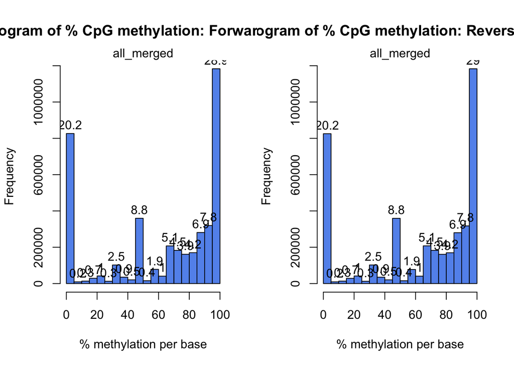

```r
getMethylationStats(myobj_merged,plot=T,both.strands=TRUE)
```

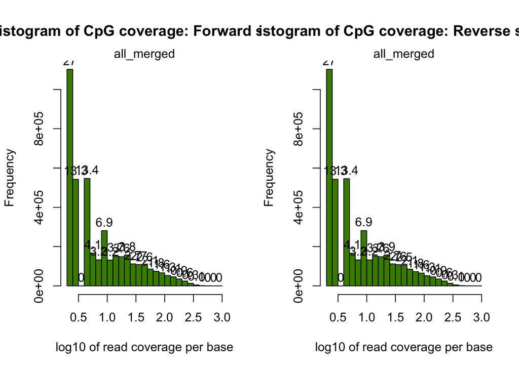

```r
getCoverageStats(myobj_merged,plot=TRUE,both.strands=TRUE)
```

Create R dataframe object from methylRaw object

```r
methdf_merged=getData(myobj_merged)
```

### Call methylation status based on % methylation

A locus is methylated if 50% or greater reads are methylated, that is they were unconverted after bisulfite treatment (in this dataset they are “C’s”) (Gavery and Roberts 2013; Olson and Roberts 2013). I will therefore determine methylation status using the numCs/coverage, where methylated = any greater or equal to 50%.

```r
methdf_merged <- methdf_merged %>%
  mutate(meth.percent=numCs/coverage,
         methyl.status=factor(ifelse(meth.percent >= 0.5, 'methylated', "unmethylated")))
```

#### How many methylated & unmethylated sites are there with various coverage thresholds?

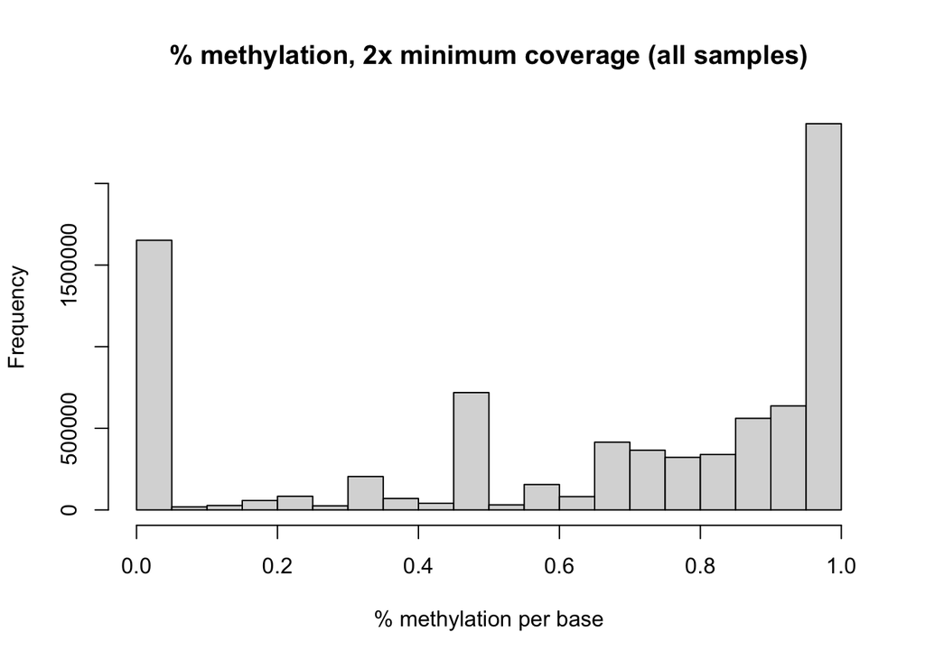

```r
hist(methdf_merged$meth.percent, col="gray85",
     xlab="% methylation per base",
     main="% methylation, 2x minimum coverage (all samples)") #note: this dataset is already filtered for 2x coverage
```

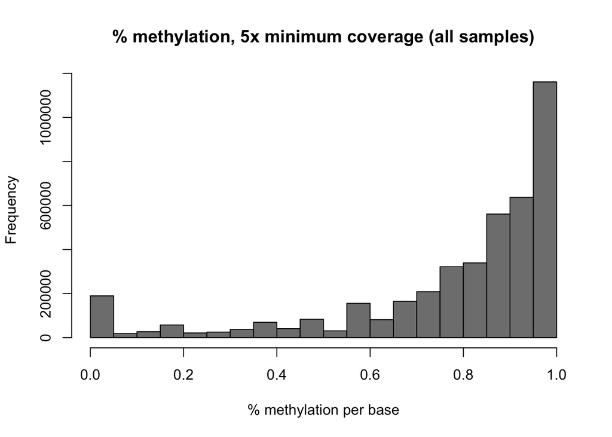

```r
hist(subset(methdf_merged, coverage >= 5)$meth.percent, col="gray50",
     xlab="% methylation per base",
     main="% methylation, 5x minimum coverage (all samples)")
```

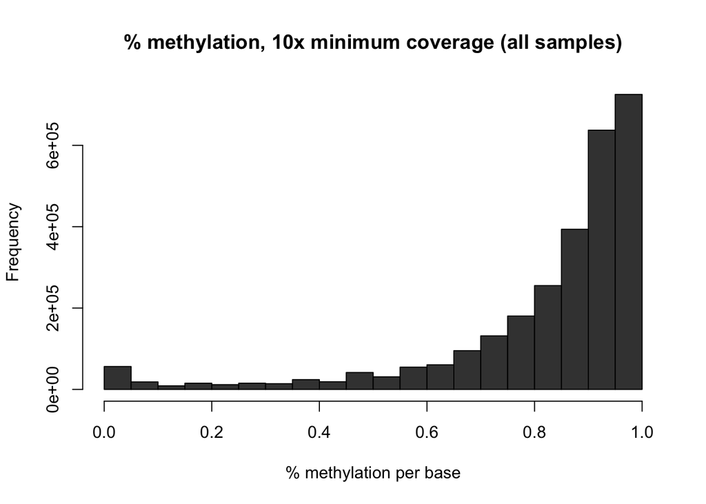

```r
hist(subset(methdf_merged, coverage >= 10)$meth.percent, col="gray25",
     xlab="% methylation per base",
     main="% methylation, 10x minimum coverage (all samples)")
```

#### Filter for only loci with 5x coverage or greater, and write out bedfiles for methylated loci, and unmethylated loci

```r
# Extract and write out methylated loci
merged_methylated_5x <- methdf_merged %>%
  mutate(start = start-1, end = end+1) %>%
  filter(coverage >=5) %>%
  filter(methyl.status=="methylated")
write_delim(merged_methylated_5x %>% dplyr::select(chr, start, end, meth.percent), "../analyses/methylation-characteristics/merged_methylated_5x.bed",  delim = '\t', col_names = TRUE)
save(merged_methylated_5x, file="../analyses/methylation-characteristics/R-objects/merged_methylated_5x")

# Extract and write out unmethylated loci
merged_unmethylated_5x <- methdf_merged %>%
  mutate(start = start-1, end = end+1) %>%
  filter(coverage >=5) %>%
  filter(methyl.status=="unmethylated")
write_delim(merged_unmethylated_5x %>% dplyr::select(chr, start, end, meth.percent), "../analyses/methylation-characteristics/merged_unmethylated_5x.bed",  delim = '\t', col_names = TRUE)

# Extract and write out all loci
merged_all_5x <- methdf_merged %>%
  mutate(start = start-1, end = end+1) %>%
  filter(coverage >=5)
write_delim(merged_all_5x %>% dplyr::select(chr, start, end, meth.percent), "../analyses/methylation-characteristics/merged_all_5x.bed",  delim = '\t', col_names = TRUE)
save(merged_all_5x, file="../analyses/methylation-characteristics/R-objects/merged_all_5x")
```

#### How many unmethylated loci are there?

```r
nrow(merged_unmethylated_5x)
```

```
## [1] 507752
```

#### How many methylated loci are there?

```r
nrow(merged_methylated_5x)
```

```
## [1] 3724318
```

#### Identify locations of methylated loci

```bash
echo "No. of methylated loci located in genes:"
bedtools intersect -wb -a "../analyses/methylation-characteristics/merged_methylated_5x.bed" -b "../genome-features/Olurida_v081-20190709.gene.gff" | wc -l
```

```
## No. of methylated loci located in genes:
##  1287036
```

```bash
echo "No. of methylated loci located in genes +/- 2kb flanks:"
bedtools intersect -wb -a "../analyses/methylation-characteristics/merged_methylated_5x.bed" -b "../genome-features/Olurida_v081-20190709.gene.2kbslop.gff" | wc -l
```

```
## No. of methylated loci located in genes +/- 2kb flanks:
##  1633269
```

```bash
echo "No. of methylated loci located in exons:"
bedtools intersect -wb -a "../analyses/methylation-characteristics/merged_methylated_5x.bed" -b "../genome-features/Olurida_v081-20190709.exon.gff" | wc -l
```

```
## No. of methylated loci located in exons:
##   546067
```

```bash
echo "No. of methylated loci located in coding sequences:"
bedtools intersect -wb -a "../analyses/methylation-characteristics/merged_methylated_5x.bed" -b "../genome-features/Olurida_v081-20190709.CDS.gff" | wc -l
```

```
## No. of methylated loci located in coding sequences:
##   498795
```

```bash
echo "No. of methylated loci located in mRNA:"
bedtools intersect -wb -a "../analyses/methylation-characteristics/merged_methylated_5x.bed" -b "../genome-features/Olurida_v081-20190709.mRNA.gff" | wc -l
```

```
## No. of methylated loci located in mRNA:
##  1287036
```

```bash
echo "No. of methylated loci located in transposable elements:"
bedtools intersect -wb -a "../analyses/methylation-characteristics/merged_methylated_5x.bed" -b "../genome-features/Olurida_v081_TE-Cg.gff" | wc -l
```

```
## No. of methylated loci located in transposable elements:
##   510903
```

```bash
echo "No. of methylated loci located in alternative splice variants:"
bedtools intersect -wb -a "../analyses/methylation-characteristics/merged_methylated_5x.bed" -b "../genome-features/20190709-Olurida_v081.stringtie.gtf" | wc -l
```

```
## No. of methylated loci located in alternative splice variants:
##  8526226
```

```bash
echo "No. of methylated loci not located in any known feature:"
bedtools intersect -v -a "../analyses/methylation-characteristics/merged_methylated_5x.bed" -b "../genome-features/Olurida_v081-20190709.gene.2kbslop.gff" "../genome-features/Olurida_v081-20190709.exon.gff" "../genome-features/Olurida_v081-20190709.CDS.gff" "../genome-features/Olurida_v081-20190709.mRNA.gff" "../genome-features/Olurida_v081_TE-Cg.gff" "../genome-features/20190709-Olurida_v081.stringtie.gtf" | wc -l
```

```
## No. of methylated loci not located in any known feature:
##  1203633
```

#### Save all of the above intersected to file

```bash
bedtools intersect -wb -a "../analyses/methylation-characteristics/merged_methylated_5x.bed" -b "../genome-features/Olurida_v081-20190709.gene.gff" >  ../analyses/methylation-characteristics/methylated-gene.bed
bedtools intersect -wb -a "../analyses/methylation-characteristics/merged_methylated_5x.bed" -b "../genome-features/Olurida_v081-20190709.gene.2kbslop.gff" >  ../analyses/methylation-characteristics/methylated-gene2kb.bed
bedtools intersect -wb -a "../analyses/methylation-characteristics/merged_methylated_5x.bed" -b "../genome-features/Olurida_v081-20190709.exon.gff" >  ../analyses/methylation-characteristics/methylated-exon.bed
bedtools intersect -wb -a "../analyses/methylation-characteristics/merged_methylated_5x.bed" -b "../genome-features/Olurida_v081-20190709.CDS.gff" >  ../analyses/methylation-characteristics/methylated-CDS.bed
bedtools intersect -wb -a "../analyses/methylation-characteristics/merged_methylated_5x.bed" -b "../genome-features/Olurida_v081-20190709.mRNA.gff" >  ../analyses/methylation-characteristics/methylated-mRNA.bed
bedtools intersect -wb -a "../analyses/methylation-characteristics/merged_methylated_5x.bed" -b "../genome-features/Olurida_v081_TE-Cg.gff" >  ../analyses/methylation-characteristics/methylated-TE.bed
bedtools intersect -wb -a "../analyses/methylation-characteristics/merged_methylated_5x.bed" -b "../genome-features/20190709-Olurida_v081.stringtie.gtf" >  ../analyses/methylation-characteristics/methylated-ASV.bed
bedtools intersect -v -a "../analyses/methylation-characteristics/merged_methylated_5x.bed" -b "../genome-features/Olurida_v081-20190709.gene.2kbslop.gff" "../genome-features/Olurida_v081-20190709.exon.gff" "../genome-features/Olurida_v081-20190709.CDS.gff" "../genome-features/Olurida_v081-20190709.mRNA.gff" "../genome-features/Olurida_v081_TE-Cg.gff" "../genome-features/20190709-Olurida_v081.stringtie.gtf" >  ../analyses/methylation-characteristics/methylated-unknown.bed
```

### Summarizing Methylation Annotations

#### Where are methylated loci located?

```r
methfiles <- c("methylated-CDS.bed", "methylated-exon.bed", "methylated-gene.bed", "methylated-gene2kb.bed", "methylated-mRNA.bed", "methylated-TE.bed", "methylated-ASV.bed", "methylated-unknown.bed")
methylated.features <- list()
for (i in c(1:8)) {
  methylated.features[[i]] <- read_delim(here::here("analyses", "methylation-characteristics", methfiles[i]), delim = '\t', col_names = FALSE) %>% as_tibble()}
for (i in 1:7) {
  methylated.features[[i]] <- methylated.features[[i]] %>%
    setNames(c("contig.meth","start.meth","end.meth","score.meth","contig.feat", "source.feat","feature","start.feat","end.feat","unknown1","strand","unknown2","attribute")) %>%
mutate(ID=str_extract(attribute, "ID=(.*?);"),
       Parent=str_extract(attribute, "Parent=(.*?);"),
       Name=str_extract(attribute, "Name=(.*?);"),
       Alias=str_extract(attribute, "Alias=(.*?);"),
       AED=str_extract(attribute, "AED=(.*?);"),
       eAED=str_extract(attribute, "eAED=(.*?);"),
       Note=str_extract(attribute, "Note=(.*?);"),
       Ontology_term=str_extract(attribute, "Ontology_term=(.*?);"),
       Dbxref=str_extract(attribute, "Dbxref=(.*?);")
       ) %>%
mutate_at("feature", as.factor)
}
names(methylated.features) <- c("methylated.CDS", "methylated.exon", "methylated.gene","methylated.gene2kb", "methylated.mRNA", "methylated.TE", "methylated.ASV", "methylated.unknown")
methylated.features[["methylated.unknown"]] <-
  methylated.features[["methylated.unknown"]] %>%
  setNames(c("contig.meth", "start.meth", "end.meth", "score.meth"))

methylated.features[["methylated.CDS"]] <- methylated.features[["methylated.CDS"]] %>% mutate_at("unknown2", as.character)
methylated.features[["methylated.TE"]] <- methylated.features[["methylated.TE"]] %>% mutate_at("unknown1", as.character)
methylated.features[["methylated.ASV"]] <- methylated.features[["methylated.ASV"]] %>% mutate_at("unknown1", as.character) %>% filter(feature=="transcript") #filter out the duplicate "exon" entry in ASV feature list
methylated.features[["methylated.gene2kb"]]$feature <- "gene2kb"
methylated.features[["methylated.unknown"]]$feature <- "unknown"
methylated.features.df <- bind_rows(methylated.features)
print(methylated.summary <- table(methylated.features.df[c("feature")]))
```

```
##
##        CDS       exon       gene    gene2kb       mRNA similarity transcript
##     498795     546067    1287036    1633269    1287036     510903    5727193
##    unknown
##    1203633
```

```r
names(methylated.summary) <- c("CDS","exon","gene","gene2kb","mRNA","TE", "ASV", "unknown") #rename columns

#save methylated loci feature df object to file, to use in notebook #12
save(methylated.features.df, file="../analyses/methylation-characteristics/R-objects/methylated.features.df")
save(methylated.summary, file="../analyses/methylation-characteristics/R-objects/methylated.summary")
```

#### Where are ALL loci located that we have data for? (this is methylated + unmethylated combined after filtering for 5x coverage)

#### Use bedtools to find overlaps between all loci and gene features

```bash
bedtools intersect -wb -a "../analyses/methylation-characteristics/merged_all_5x.bed" -b "../genome-features/Olurida_v081-20190709.gene.gff" >  ../analyses/methylation-characteristics/all-gene.bed
bedtools intersect -wb -a "../analyses/methylation-characteristics/merged_all_5x.bed" -b "../genome-features/Olurida_v081-20190709.gene.2kbslop.gff" >  ../analyses/methylation-characteristics/all-gene2kb.bed
bedtools intersect -wb -a "../analyses/methylation-characteristics/merged_all_5x.bed" -b "../genome-features/Olurida_v081-20190709.exon.gff" >  ../analyses/methylation-characteristics/all-exon.bed
bedtools intersect -wb -a "../analyses/methylation-characteristics/merged_all_5x.bed" -b "../genome-features/Olurida_v081-20190709.CDS.gff" >  ../analyses/methylation-characteristics/all-CDS.bed
bedtools intersect -wb -a "../analyses/methylation-characteristics/merged_all_5x.bed" -b "../genome-features/Olurida_v081-20190709.mRNA.gff" >  ../analyses/methylation-characteristics/all-mRNA.bed
bedtools intersect -wb -a "../analyses/methylation-characteristics/merged_all_5x.bed" -b "../genome-features/Olurida_v081_TE-Cg.gff" >  ../analyses/methylation-characteristics/all-TE.bed
bedtools intersect -wb -a "../analyses/methylation-characteristics/merged_all_5x.bed" -b "../genome-features/20190709-Olurida_v081.stringtie.gtf" >  ../analyses/methylation-characteristics/all-ASV.bed
bedtools intersect -v -a "../analyses/methylation-characteristics/merged_all_5x.bed" -b "../genome-features/Olurida_v081-20190709.gene.2kbslop.gff" "../genome-features/Olurida_v081-20190709.exon.gff" "../genome-features/Olurida_v081-20190709.CDS.gff" "../genome-features/Olurida_v081-20190709.mRNA.gff" "../genome-features/Olurida_v081_TE-Cg.gff" "../genome-features/20190709-Olurida_v081.stringtie.gtf" >  ../analyses/methylation-characteristics/all-unknown.bed
```

```r
methfiles <- c("all-CDS.bed", "all-exon.bed", "all-gene.bed", "all-gene2kb.bed", "all-mRNA.bed", "all-TE.bed", "all-ASV.bed", "all-unknown.bed")
all.features <- list()
for (i in c(1:8)) {
  all.features[[i]] <- read_delim(here::here("analyses", "methylation-characteristics", methfiles[i]), delim = '\t', col_names = FALSE) %>% as_tibble()}
for (i in 1:7) {
  all.features[[i]] <- all.features[[i]] %>%
    setNames(c("contig.meth","start.meth","end.meth","score.meth","contig.feat", "source.feat","feature","start.feat","end.feat","unknown1","strand","unknown2","attribute")) %>%
mutate(ID=str_extract(attribute, "ID=(.*?);"),
       Parent=str_extract(attribute, "Parent=(.*?);"),
       Name=str_extract(attribute, "Name=(.*?);"),
       Alias=str_extract(attribute, "Alias=(.*?);"),
       AED=str_extract(attribute, "AED=(.*?);"),
       eAED=str_extract(attribute, "eAED=(.*?);"),
       Note=str_extract(attribute, "Note=(.*?);"),
       Ontology_term=str_extract(attribute, "Ontology_term=(.*?);"),
       Dbxref=str_extract(attribute, "Dbxref=(.*?);")
       ) %>%
mutate_at("feature", as.factor)
}
names(all.features) <- c("all.CDS", "all.exon", "all.gene","all.gene2kb", "all.mRNA", "all.TE", "all.ASV", "all.unknown")
all.features[["all.unknown"]] <-
  all.features[["all.unknown"]] %>%
  setNames(c("contig.meth", "start.meth", "end.meth", "score.meth"))

all.features[["all.CDS"]] <- all.features[["all.CDS"]] %>% mutate_at("unknown2", as.character)
all.features[["all.TE"]] <- all.features[["all.TE"]] %>% mutate_at("unknown1", as.character)
all.features[["all.ASV"]] <- all.features[["all.ASV"]] %>% mutate_at("unknown1", as.character) %>% filter(feature=="transcript") #filter out the duplicate "exon" entry in ASV feature list
all.features[["all.gene2kb"]]$feature <- "gene2kb"
all.features[["all.unknown"]]$feature <- "unknown"
all.features.df <- bind_rows(all.features)
print(all.summary <- table(all.features.df[c("feature")]))
```

```
##
##        CDS       exon       gene    gene2kb       mRNA similarity transcript
##     534693     586000    1415193    1811780    1415193     595183    6209825
##    unknown
##    1422304
```

```r
names(all.summary) <- c("CDS","exon","gene","gene2kb","mRNA","TE", "ASV", "unknown") #rename columns

#save all loci feature df object to file, to use in notebook #12
save(all.features.df, file="../analyses/methylation-characteristics/R-objects/all.features.df")
save(all.summary, file="../analyses/methylation-characteristics/R-objects/all.summary")
```

### Prep summary df that contains locations of methylated loci & all loci, and % of those loci that are located within known features

```r
methylation.overlap <-  merge(x=melt(methylated.summary, varnames = "feature", value.name = "methylated"),
                              y=melt(all.summary, varnames = "feature", value.name = "all")) #convert to long format

methylation.overlap <- methylation.overlap %>% mutate(feature = as.character(feature)) %>% #make feature character class
  mutate(methylated=as.numeric(methylated)) %>%  #make # methylated loci numeric class
  rbind(c("geneflank2kb",methylation.overlap[methylation.overlap$feature=="gene2kb","methylated"]-methylation.overlap[methylation.overlap$feature=="gene","methylated"],
          methylation.overlap[methylation.overlap$feature=="gene2kb","all"]-methylation.overlap[methylation.overlap$feature=="gene","all"])) %>% #add row with # loci that flannk genes (up & down)
  rbind(c("intron",methylation.overlap[methylation.overlap$feature=="gene","methylated"]-methylation.overlap[methylation.overlap$feature=="exon","methylated"],
          methylation.overlap[methylation.overlap$feature=="gene","all"]-methylation.overlap[methylation.overlap$feature=="exon","all"])) %>% #add row with # loci in introns (# in genes minus # in exons)
  rbind(c("all", as.numeric(nrow(merged_methylated_5x)), as.numeric(nrow(merged_all_5x)))) %>% #add row with total # methylated loci
  mutate_at(vars(-feature), funs(as.numeric)) %>% #convert all columns to numeric (except feature column)
  mutate(methperc=methylated/nrow(merged_methylated_5x), allperc=all/nrow(merged_all_5x)) #calculate % of loci that overlap with known features
save(methylation.overlap, file="../analyses/methylation-characteristics/R-objects/methylation.overlap")

methylation.overlap.long <- cbind(melt(methylation.overlap[,c("feature", "methylated", "all")],
                                  variable.name = "analysis", value.name = "count"),
                             melt(methylation.overlap[,c("feature", "methperc","allperc")],
                                  variable.name = "analysis", value.name = "percent"))[,c(1,2,3,6)] %>%
  mutate(feature=fct_relevel(as.factor(feature), c("gene", "gene2kb", "exon", "intron", "geneflank2kb", "CDS", "mRNA", "TE", "ASV", "unknown", "all")),
         analysis=fct_relevel(as.factor(analysis), c("all", "methylated")))
```

### Summary barplot showing where methylated loci and all loci overlap with known gene features (and unknown)

NOTE: Summary barplot should also include all CpG loci in Oly genome. Need to add.

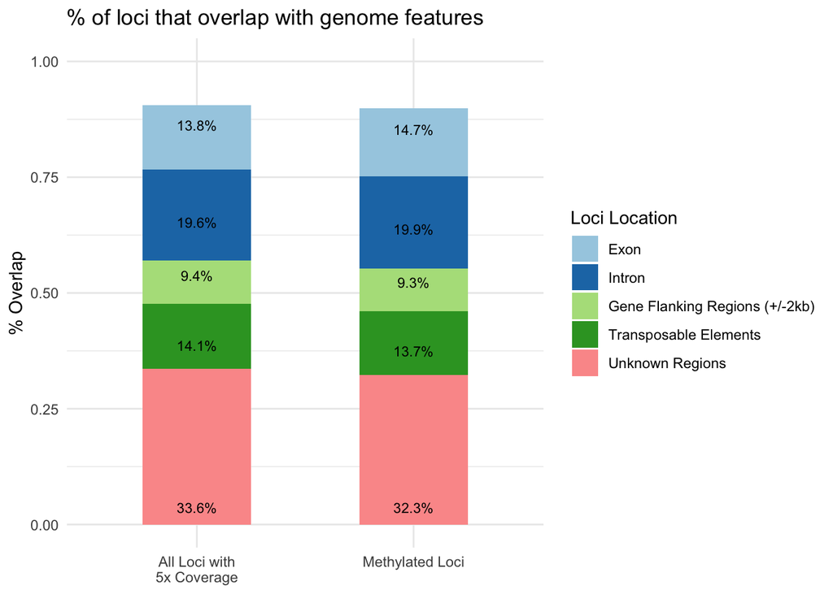

```r
ggplot(data=subset(methylation.overlap.long, feature=="geneflank2kb" | feature=="exon" | feature=="intron" |feature=="TE" | feature=="unknown"), aes(x=analysis, y=percent, fill=feature, label=percent(percent, accuracy = 0.1))) +  #prettyNum(count, big.mark = ",")
  geom_bar(stat="identity", width = .5) +
#  geom_bar(stat="identity", position="fill", width=0.5) + #use this instead for stacked bp to total 100%
  scale_fill_manual(name = "Loci Location", labels = c("Exon", "Intron", "Gene Flanking Regions (+/-2kb)", "Transposable Elements", "Unknown Regions"),
                    values=c("#a6cee3", "#1f78b4", "#b2df8a","#33a02c", "#fb9a99")) +
  ggtitle("% of loci that overlap with genome features") +
  labs(y="% Overlap", x=NULL) +
  theme_minimal() + geom_text(size = 3, position = position_fill(vjust = 0.1)) +
  scale_x_discrete(labels=c(all="All Loci with\n5x Coverage", "methylated" = "Methylated Loci"))
```